# MLcourseProject - Deep Learning Your Brain

## Classification of Movement Execution and Imagination using EEG Signals

This repository is for the Advanced Topics in ML project Spring Semester 2019.

## Group members:

Tim Fischer, Özhan Özen, Joaquin Penalver-Andres

## Project Description:

The project will focus on classification of movement imagination and movement tasks using EEG signals.

It has been proven that the mental planning or execution of different movements, produces different neuronal footprints. These footprints can be detected by means of an EEG recording device. The goal of this project is to classify different movements that subjects may think of or execute.

## Motivation

By decoding the EEG Signal, creating a so called "Brain-Computer-Interface" is possible. A BCI is able to decode human intent from brain activity to create an alternate communication channel. In our case decoding imaginary movement planning from the eeg, could help impaired people to move a prosthesis in the desired direction.

For more details on BCIs see https://towardsdatascience.com/a-beginners-guide-to-brain-computer-interface-and-convolutional-neural-networks-9f35bd4af948.

## Report

Please note that the report.html (which is basically the export of notebook) is under the folder ProjectCode. This readme file has almost the same content.

# EEG

According to the wikipedia definition (https://en.wikipedia.org/wiki/Electroencephalography):

"Electroencephalography (EEG) is an electrophysiological monitoring method to record electrical activity of the brain. It is typically noninvasive, with the electrodes placed along the scalp, although invasive electrodes are sometimes used, as in electrocorticography. EEG measures voltage fluctuations resulting from ionic current within the neurons of the brain. Clinically, EEG refers to the recording of the brain's spontaneous electrical activity over a period of time, as recorded from multiple electrodes placed on the scalp. Diagnostic applications generally focus either on event-related potentials or on the spectral content of EEG. The former investigates potential fluctuations time locked to an event, such as 'stimulus onset' or 'button press'. The latter analyses the type of neural oscillations (popularly called "brain waves") that can be observed in EEG signals in the frequency domain. "

[figure not shown]

##### The pictures are taken from physionet and wikipedia, respectively.

# Resources

## Dataset

We will base our project on an existing dataset (link: https://www.physionet.org/physiobank/database/eegmmidb/#experimental-protocol ).

The physionet dataset contains the following classes, with 109 subjects and 64 EGG Channels (Subjects 88, 92 and 100 have overlapping events. Please exclude these subjects).

## LABELS | DESCRIPTION

0 | Baseline, eyes open  
1 | Baseline, eyes closed  
2 | Motor execution: Left Hand  
3 | Motor execution: Right Hand  
4 | Motor imagery: Left Hand  
5 | Motor imagery: Right Hand  
6 | Motor execution: Both Hands  
7 | Motor execution: Both Feet  
8 | Motor Im: Both Hands  
9 | Motor imagery: Both Feet

We have chosen to include 8 classes (baselines are excluded) for classification.

## Tools Used

- Pytorch (For NN training)
- MNE python (For downloading/loading eeg data and creating epochs)
- Many other basic python modules for data processing
- The final test were done on a Ubuntu with two GPU
- Tensorflow (for tensorboard visualization)

  ```
    To run the TensorBoard, open a new terminal, go to the ProjectCode folder and run the command `$ tensorboard --logdir=./logs --port=6006`. Then, open http://localhost:6006/ on your web browser. If you have logs in your log dir, you will see nice graphs ;)

    (logdir should point to the log directory of your created logs)

    Logs can be created by calling write_logs_for_tensorboard() -> Feel free to modify, extend this function or add more tensorboard functions for further analysis of network performance.
  ```

## Literature Used or Inspired:

[1] Zhang, D., Yao, L., Wang, S., Chen, K., Yang, Z., & Benatallah,B. (2018, June). Fuzzy integral optimization with deep q-network for eeg-based intention recognition. In Pacific-Asia Conference on Knowledge Discovery and Data Mining (pp. 156-168). Springer, Cham. https://github.com/dalinzhang/Cascade-Parallel/

[2] Schirrmeister, R. T., Springenberg, J. T., Fiederer, L. D. J., Glasstetter, M., Eggensperger, K., Tangermann, M., ... & Ball, T. (2017). Deep learning with convolutional neural networks for EEG decoding and visualization. Human brain mapping, 38(11), 5391-5420.

[3] Yannick, R., Hubert, B., Isabela, A., Alexandre, G., & Jocelyn, F. (2019). Deep learning-based electroencephalography analysis: a systematic review. arXiv preprint arXiv:1901.05498.

[4] Lawhern, V. J., Solon, A. J., Waytowich, N. R., Gordon, S. M., Hung, C. P., & Lance, B. J. (2018). EEGNet: a compact convolutional neural network for EEG-based brain–computer interfaces. Journal of neural engineering, 15(5), 056013. https://github.com/vlawhern/arl-eegmodels https://github.com/aliasvishnu/EEGNet

[5] https://robintibor.github.io/braindecode/

[6] https://martinos.org/mne/stable/auto_examples/decoding/plot_decoding_csp_eeg.html#sphx-glr-auto-examples-decoding-plot-decoding-csp-eeg-py

# Neural Networks and Training:

## Pre-processing

- The epochs are taken to cover 2s on movement (trigger) offset with 160 samples per second.
- Each epoch data are normalized to have zero mean and standard deviation of 1.
- Augmentation of data with gaussian noise and inpainting-like data removal for regularization are tried (both in time and channel axis), however, we could not detect significant difference.
- 20 subjects were included, with 8 classes (no baseline).
- Cropping the time axis in small windows (of 10 samples) was suggested in literature [1], we have followed the suggestion. Each network is trained with and without this technique.
- For 3D CNN, the 64 channels are mapped to their locations in the head as a 2D grid (11x10). In order to make this location information a rectangle, zeros are added where there is no electrode on the grid [1].
- Eventually the data shape were (nEpochs,nChannels,nSamples), (nEpochs,nChannelsX,nChannelsY,nSamples), (nEpochs*nWindows,nChannels,nSamples) or (nEpochs*nWindows,nChannelsX,nChannelsY,nSamples) depending on whether the time axis is cropped or not and whether it was 2D or 3D CNN.

## Neural Networks Trained

[figure not shown]

### 1) 3D CNN (The network is almost the same as in [1])

- Layer 1 -- (32x1x11x10x10--cropped) or (32x1x11x10x320--non_cropped) + ExpoRU (CELU) + BatchNorm
- Layer 2 -- (64x1x11x10x10--cropped) or (64x1x11x10x320--non_cropped) + ExpoRU (CELU) + BatchNorm
- Layer 3 -- (128x1x11x10x10--cropped) or (128x1x11x10x320--non_cropped) + ExpoRU (CELU) + BatchNorm
- Layer 4 -- (Flatten fully connected Linear, Droput=0.5)

  #### Note: All the kernel sizes were (3,3,3) with stride 1, and padding such that there were no reduction on the size.

### 2) 2D CNN (similar to the first network, but for 1D channel grid)

- Layer 1 -- (32x1x64x10--cropped) or (32x1x64x320--non_cropped) + ExpoRU (CELU) + BatchNorm
- Layer 2 -- (64x1x64x10--cropped) or (64x1x64x320--non_cropped) + ExpoRU (CELU) + BatchNorm
- Layer 3 -- (128x1x64x10--cropped) or (128x1x64x320--non_cropped) + ExpoRU (CELU) + BatchNorm
- Layer 4 -- (Flatten fully connected Linear, Droput=0.5)

  #### Note: All the kernel sizes were (7,3) with stride 1, and padding such that there were no reduction on the size.

### For all the trainings, ADAM optimizer (lr:1e-3, weight decay:1e-4, scheduler with 20 steps and gamma 0.5), and Cross Entropy Loss (with sigmoid activation in the output) are used. Batch size was either 128 or 256.

# Results

The accuracy on the test sets for both CNNs with both cropped and non-cropped (of time axis) epochs are below. The in-class accuracy on the right is given for 3D-CNN cropped.

[figure not shown]

As you see, cropping the time axis in time windows (of 10 samples) makes a huge difference.

An explanation of Schirrmeister et al. (2017) in arXiv:1703.05051v5 states that "cropping has the aim to force the ConvNet into using features that are present in all crops of the trial, since the ConvNet can no longer use the differences between crops and the global temporal structure."

The training progress for accuracy and loss for cropped epochs are below.

[figure not shown]

The training progress for accuracy and loss for non-cropped epochs are below. You could see the huge overfitting.

[figure not shown]

# Discussion

From the results, we see a huge benefit of using cropped 10 sample windows as input. This was mainly suggested in literature (and using sizes of 10 samples [1]). Doing this, instead of taking all the recording as a single window results in a trade-off, which seemed like a good one for our project. When we crop small windows of the data, we make the network focus on repeating (or consistent) local temporal features such as the frequency of the signals. On the other side, we loose the global temporal changes. For example, if it is common that with one of the tasks (labels), there is a systematic drift over time (320 time points), we will not be able to detect this. However, for our example it seemed like the most of the representative information was contained in this small windows since this time cropping increased the network classification accuracy a lot.

Between 2D and 3D CNNs, we see that 3D performs better (cropped versions). This is consistent with the literature and intuitive. Since the electrodes are having a layout which physiologically makes sense in 3D version (the way they are attached to the head), the layout brings additional information, and this increases the accuracy.

We have implemented and tried different augmenting the data with gaussian noise, and dropping some parts of the information similar to inpainting. However we could not detect a significant benefit. Furthermore, since we had always the opportunity of using data from more subjects (we have used 20 out of 109), data augmentation was not our focus.

# Future Works

What we think could be future work that may benefit the project are:

- Utilizing RNNs with CNNs to include the global temporal change information as it was done in [1].
- Making adaptive kernel sizes for CNN (and for cropping windows sizes) to extract optimal frequency features.
- Using autoencoders to extract recurring patterns, and using these to increase classification accuracy.
- Using Transfer learning to utilize this dataset on other EEG applications.

# Code: How-to

- In order to run the project, you need to open the 'Main' jupyter notebook and run it from top to bottom.
- All parameters necessary for adapting the classification can be modified inside the config/<myconfig.py> files. To store specific settings, just add a class to myconfig.py, inheriting from DefaultConfig.
- Put your configs which shall be evaluated inside the list_of_configs in the myconfig.py module.
- Inside the main.py: Select your config via myList = myconfig.list_of_configs
- In case of supplementary optimizers or nn, please add them to the optimizers.py or neural_nets package. Adapt the optimizer_list or nn_list (+nn_models_getter.py) the in the defaultconifg.py respectively.

## Example config file to run any NN implemented/tested

#### Config class name to include in the list at the bottom.

```
class Config3DCNN_NOTCropped(DefaultConfig):
    verbose = 'CRITICAL'

    config_name = '3D CNN'
    config_remark = '3D CNN'
```

#### Number of subjects.

```
nSubj = 20
selected_subjects = selected_subjects[:nSubj]
```

#### Selection of the network and optimizer, these names have to be in .py files.

```
nn_list = ['ConvNet3D']  # Extend if you want more. Add them in the nn_models_getter.py module
nn_selection_idx = 0
optimizer_list = ['Adam']  # Extend if you want more. Add them in the optimizers.py module
optimizer_selection_idx = 0  # Idx corresponds to entry optimizer_list (find below)
learning_rate = 1e-3
weight_decay = 1e-4
```

#### Setting up a scheduler for learning rate.

```
scheduler = True
schStepSize = 20
schGamma = 0.5
```

#### Number of epochs and early stopping settings.

```
num_of_epochs = 50
batch_size = 128
use_early_stopping = True
es_patience = num_of_epochs
```

#### Normalization/augmentation settings

```
normalize = True
augment_with_gauss_noise = False
augmentation_factor = 2
augment_std_gauss = 0.2
dropOut = False
dropOutChOnly = False
dropOutTimeOnly = False
dropOutTilePerc = 0.5
dropOutTimeTile = 40
dropOutChannelTile = 8
```

#### Epoch Settings

```
time_before_event_s = 0.0  # Epochsize parameter: Start time before event.
time_after_event_s = 2.0  # Epochsize parameter: Time after event.
downSample = 1
```

#### To make number of data points dividable with 10

```
show_events_distribution = False
removeLastData = True
```

#### To make channel dimension 2d, or cropping the time axis.

```
Elec2D = True
wSize = 10
wCropped = False
```

#### All the classes in this list will be trained.

[output not shown]

# START OF THE CODE BELOW

## Loading of Modules

```python
%matplotlib inline
#%matplotlib widget
%load_ext autoreload
%autoreload 2


import numpy as np
from visualisations import eeg_sample_plot, events_distribution_plot, curve_name_gen
from sklearn.model_selection import train_test_split
from torchvision.transforms import Compose, ToTensor
from torch.utils.data import DataLoader
from datasets import ChannelsVoltageDataset
from neural_nets.nn_models_getter import get_nn_model
from optimizers import get_optimizer
from utils_train import fit, test, plot_all_metrics, plot_val_metrics, final_test_acc
from configs import configs_ozhan, configs_tim, configs_joaquin, configs_final
from data_loader_creation import get_dataloader_objects
from classification_results import results_storer
from datetime import datetime
import torch
import matplotlib.pyplot as plt
```

## Selecting the configuration (configs_final is the final one)

```python
""" USER: SELECT THE CONFIGURATION YOU NEED """
myList = configs_final.list_of_configs
```

## Trainining, plotting and saving the models

```
 3D-CNN-tAxisNOTCropped
-------------------------

We are not on the cluster...

Data is being loaded using MNE...
```

```
3600 matching events found
No baseline correction applied
...data loading with MNE was finished.

Dataset is being made 2D...
Data is now 2D.

Normalizing data...
...data was normalized.

320  time samples and  10  EEG channels for one epoch are taken.  Total epoch number is  3600  and there are  20  subjects included.
 There are in total  8  classes for classification.


Expected network layer output shapes:
Input: [1, 11, 10, 320]
Layer 1 Out: [32, 11, 10, 320]
Layer 2 Out: [64, 11, 10, 320]
Layer 3 Out: [128, 11, 10, 320]
Linear Layer Features: 4505600

cuda will be used for training of this model.
You have 2 GPUs for training!
Learning Rate:  0.001

-> Epoch 1/50: train_loss: 138.2285, train_accuracy: 22.7366%, val_loss: 115.8578, val_accuracy: 19.7531%
-> Epoch 2/50: train_loss: 94.9764, train_accuracy: 34.8765%, val_loss: 106.6442, val_accuracy: 23.1481%
-> Epoch 3/50: train_loss: 67.0529, train_accuracy: 46.7421%, val_loss: 149.4417, val_accuracy: 24.6914%
-> Epoch 4/50: train_loss: 50.1378, train_accuracy: 57.1331%, val_loss: 135.7571, val_accuracy: 27.1605%
-> Epoch 5/50: train_loss: 32.7816, train_accuracy: 66.5295%, val_loss: 128.3159, val_accuracy: 27.4691%
-> Epoch 6/50: train_loss: 20.1300, train_accuracy: 75.5487%, val_loss: 138.8983, val_accuracy: 27.1605%
-> Epoch 7/50: train_loss: 12.0231, train_accuracy: 82.3731%, val_loss: 129.6008, val_accuracy: 25.6173%
-> Epoch 8/50: train_loss: 8.4689, train_accuracy: 86.2140%, val_loss: 140.0710, val_accuracy: 24.6914%
-> Epoch 9/50: train_loss: 7.0480, train_accuracy: 88.9918%, val_loss: 140.6898, val_accuracy: 26.2346%
-> Epoch 10/50: train_loss: 5.3582, train_accuracy: 90.8436%, val_loss: 134.9834, val_accuracy: 26.2346%
-> Epoch 11/50: train_loss: 4.1654, train_accuracy: 92.5583%, val_loss: 151.7775, val_accuracy: 25.3086%
-> Epoch 12/50: train_loss: 3.2266, train_accuracy: 94.8217%, val_loss: 146.5762, val_accuracy: 25.9259%
-> Epoch 13/50: train_loss: 2.2249, train_accuracy: 94.9931%, val_loss: 140.8807, val_accuracy: 27.1605%
-> Epoch 14/50: train_loss: 2.5591, train_accuracy: 94.6502%, val_loss: 145.0892, val_accuracy: 25.3086%
-> Epoch 15/50: train_loss: 1.4629, train_accuracy: 96.8107%, val_loss: 152.7864, val_accuracy: 27.1605%
```

[output cut: 47 more lines]

```
Accuracy of class 3 : 26 % of 45 labels
Accuracy of class 4 : 31 % of 45 labels
Accuracy of class 5 : 26 % of 45 labels
Accuracy of class 6 : 31 % of 45 labels
Accuracy of class 7 : 24 % of 45 labels




 2D-CNN-tAxisNOTCropped
-------------------------

We are not on the cluster...

Data is being loaded using MNE...
```

```
3600 matching events found
No baseline correction applied
...data loading with MNE was finished.

Normalizing data...
...data was normalized.

320  time samples and  64  EEG channels for one epoch are taken.  Total epoch number is  3600  and there are  20  subjects included.
 There are in total  8  classes for classification.


Expected network layer output shapes:
Input: [1, 64, 320]
Layer 1 Out: [32, 64, 320]
Layer 2 Out: [64, 64, 320]
Layer 3 Out: [128, 64, 320]
Linear Layer Features: 2621440

cuda will be used for training of this model.
You have 2 GPUs for training!
Learning Rate:  0.001

-> Epoch 1/50: train_loss: 63.8631, train_accuracy: 20.4047%, val_loss: 66.8083, val_accuracy: 20.6790%
-> Epoch 2/50: train_loss: 49.6965, train_accuracy: 33.9163%, val_loss: 58.4162, val_accuracy: 30.8642%
-> Epoch 3/50: train_loss: 37.5068, train_accuracy: 47.0850%, val_loss: 67.7114, val_accuracy: 31.7901%
-> Epoch 4/50: train_loss: 25.4048, train_accuracy: 57.8189%, val_loss: 71.3693, val_accuracy: 31.4815%
-> Epoch 5/50: train_loss: 20.6693, train_accuracy: 67.7641%, val_loss: 73.7112, val_accuracy: 31.7901%
-> Epoch 6/50: train_loss: 12.5689, train_accuracy: 74.2112%, val_loss: 80.9126, val_accuracy: 31.4815%
-> Epoch 7/50: train_loss: 7.5085, train_accuracy: 81.6872%, val_loss: 73.0752, val_accuracy: 35.1852%
-> Epoch 8/50: train_loss: 5.7156, train_accuracy: 85.4595%, val_loss: 73.9255, val_accuracy: 33.3333%
-> Epoch 9/50: train_loss: 2.7529, train_accuracy: 91.4952%, val_loss: 76.7199, val_accuracy: 30.8642%
-> Epoch 10/50: train_loss: 1.8115, train_accuracy: 93.5871%, val_loss: 75.5991, val_accuracy: 33.6420%
-> Epoch 11/50: train_loss: 1.3904, train_accuracy: 93.9300%, val_loss: 76.6707, val_accuracy: 33.0247%
-> Epoch 12/50: train_loss: 1.3248, train_accuracy: 94.8560%, val_loss: 77.5178, val_accuracy: 33.9506%
-> Epoch 13/50: train_loss: 1.0122, train_accuracy: 95.7133%, val_loss: 80.0872, val_accuracy: 33.0247%
-> Epoch 14/50: train_loss: 0.8310, train_accuracy: 96.2963%, val_loss: 79.1347, val_accuracy: 34.2593%
-> Epoch 15/50: train_loss: 0.9355, train_accuracy: 96.2277%, val_loss: 77.0691, val_accuracy: 31.7901%
-> Epoch 16/50: train_loss: 0.6810, train_accuracy: 97.0850%, val_loss: 81.9279, val_accuracy: 31.1728%
-> Epoch 17/50: train_loss: 0.5008, train_accuracy: 97.7366%, val_loss: 77.1578, val_accuracy: 31.4815%
-> Epoch 18/50: train_loss: 0.5183, train_accuracy: 97.3594%, val_loss: 79.7654, val_accuracy: 32.7160%
```

[output cut: 44 more lines]

```
Accuracy of class 3 : 29 % of 44 labels
Accuracy of class 4 : 40 % of 45 labels
Accuracy of class 5 : 31 % of 45 labels
Accuracy of class 6 : 28 % of 45 labels
Accuracy of class 7 : 24 % of 45 labels




 3D-CNN-tAxisCropped
-------------------------

We are not on the cluster...

Data is being loaded using MNE...
```

```
3600 matching events found
No baseline correction applied
...data loading with MNE was finished.

Dataset is being made 2D...
Data is now 2D.

Normalizing data...
...data was normalized.

Dataset is being cropped in time axis...
Dataset is cropped. From shape (3600, 10, 11, 320) to (226800, 10, 11, 10)

10  time samples and  10  EEG channels for one epoch are taken.  Total epoch number is  226800  and there are  20  subjects included.
 There are in total  8  classes for classification.


Expected network layer output shapes:
Input: [1, 11, 10, 10]
Layer 1 Out: [32, 11, 10, 10]
Layer 2 Out: [64, 11, 10, 10]
Layer 3 Out: [128, 11, 10, 10]
Linear Layer Features: 140800

cuda will be used for training of this model.
You have 2 GPUs for training!
Learning Rate:  0.001

-> Epoch 1/50: train_loss: 3.2221, train_accuracy: 19.5860%, val_loss: 2.1471, val_accuracy: 27.5769%
-> Epoch 2/50: train_loss: 2.1778, train_accuracy: 30.1130%, val_loss: 1.8519, val_accuracy: 36.1699%
-> Epoch 3/50: train_loss: 1.6615, train_accuracy: 39.9993%, val_loss: 1.4837, val_accuracy: 47.5652%
-> Epoch 4/50: train_loss: 1.4107, train_accuracy: 48.1667%, val_loss: 1.3104, val_accuracy: 52.9199%
-> Epoch 5/50: train_loss: 1.2664, train_accuracy: 53.7467%, val_loss: 1.1761, val_accuracy: 57.3241%
-> Epoch 6/50: train_loss: 1.1643, train_accuracy: 57.7112%, val_loss: 1.1694, val_accuracy: 60.7339%
-> Epoch 7/50: train_loss: 1.0878, train_accuracy: 60.4916%, val_loss: 1.0572, val_accuracy: 62.1105%
-> Epoch 8/50: train_loss: 1.0232, train_accuracy: 62.9368%, val_loss: 0.9966, val_accuracy: 63.8889%
-> Epoch 9/50: train_loss: 0.9715, train_accuracy: 64.8273%, val_loss: 0.9741, val_accuracy: 65.8338%
-> Epoch 10/50: train_loss: 0.9247, train_accuracy: 66.8272%, val_loss: 0.9595, val_accuracy: 66.9900%
-> Epoch 11/50: train_loss: 0.8836, train_accuracy: 68.0433%, val_loss: 0.9027, val_accuracy: 68.0678%
-> Epoch 12/50: train_loss: 0.8484, train_accuracy: 69.4722%, val_loss: 0.8996, val_accuracy: 67.9159%
```

[output cut: 50 more lines]

```
Accuracy of class 3 : 76 % of 2804 labels
Accuracy of class 4 : 80 % of 2860 labels
Accuracy of class 5 : 76 % of 2810 labels
Accuracy of class 6 : 76 % of 2841 labels
Accuracy of class 7 : 77 % of 2829 labels




 2D-CNN-tAxisCropped
-------------------------

We are not on the cluster...

Data is being loaded using MNE...
```

```
3600 matching events found
No baseline correction applied
...data loading with MNE was finished.

Normalizing data...
...data was normalized.

Dataset is being cropped in time axis...
Dataset is cropped. From shape (3600, 64, 320) to (226800, 64, 10)

10  time samples and  64  EEG channels for one epoch are taken.  Total epoch number is  226800  and there are  20  subjects included.
 There are in total  8  classes for classification.


Expected network layer output shapes:
Input: [1, 64, 10]
Layer 1 Out: [32, 64, 10]
Layer 2 Out: [64, 64, 10]
Layer 3 Out: [128, 64, 10]
Linear Layer Features: 81920

cuda will be used for training of this model.
You have 2 GPUs for training!
Learning Rate:  0.001

-> Epoch 1/50: train_loss: 2.6777, train_accuracy: 20.6839%, val_loss: 1.9307, val_accuracy: 29.1691%
-> Epoch 2/50: train_loss: 1.9287, train_accuracy: 33.4520%, val_loss: 1.7151, val_accuracy: 41.0543%
-> Epoch 3/50: train_loss: 1.5590, train_accuracy: 43.2273%, val_loss: 1.4225, val_accuracy: 47.6092%
-> Epoch 4/50: train_loss: 1.3893, train_accuracy: 49.3228%, val_loss: 1.3079, val_accuracy: 52.1801%
-> Epoch 5/50: train_loss: 1.2911, train_accuracy: 52.9585%, val_loss: 1.2276, val_accuracy: 55.3351%
-> Epoch 6/50: train_loss: 1.2183, train_accuracy: 55.7221%, val_loss: 1.1825, val_accuracy: 57.4270%
-> Epoch 7/50: train_loss: 1.1573, train_accuracy: 57.9648%, val_loss: 1.1457, val_accuracy: 58.2549%
-> Epoch 8/50: train_loss: 1.1101, train_accuracy: 59.7764%, val_loss: 1.1248, val_accuracy: 59.2985%
-> Epoch 9/50: train_loss: 1.0670, train_accuracy: 61.4366%, val_loss: 1.0764, val_accuracy: 61.2728%
-> Epoch 10/50: train_loss: 1.0276, train_accuracy: 62.9684%, val_loss: 1.0432, val_accuracy: 62.2036%
-> Epoch 11/50: train_loss: 0.9903, train_accuracy: 64.2737%, val_loss: 1.0239, val_accuracy: 63.4137%
-> Epoch 12/50: train_loss: 0.9613, train_accuracy: 65.3777%, val_loss: 1.0270, val_accuracy: 62.9581%
-> Epoch 13/50: train_loss: 0.9329, train_accuracy: 66.3509%, val_loss: 0.9892, val_accuracy: 64.6140%
-> Epoch 14/50: train_loss: 0.9076, train_accuracy: 67.2355%, val_loss: 0.9668, val_accuracy: 65.2410%
-> Epoch 15/50: train_loss: 0.8824, train_accuracy: 68.3313%, val_loss: 0.9620, val_accuracy: 65.9759%
```

[output cut: 37 more lines]

```
-> Epoch 49/50: train_loss: 0.4424, train_accuracy: 84.1248%, val_loss: 0.8234, val_accuracy: 73.2608%
-> Epoch 50/50: train_loss: 0.4431, train_accuracy: 84.1809%, val_loss: 0.8218, val_accuracy: 72.8934%
Time spend for training:  1:33:00.025172  hh:mm:ss.ms


Performance on the test set:
->test_loss: 0.8236, test_accuracy: 73.0732%
Accuracy of class 0 : 77 % of 2804 labels
Accuracy of class 1 : 75 % of 2866 labels
Accuracy of class 2 : 69 % of 2866 labels
Accuracy of class 3 : 70 % of 2804 labels
Accuracy of class 4 : 74 % of 2860 labels
Accuracy of class 5 : 74 % of 2810 labels
Accuracy of class 6 : 69 % of 2841 labels
Accuracy of class 7 : 72 % of 2829 labels
```

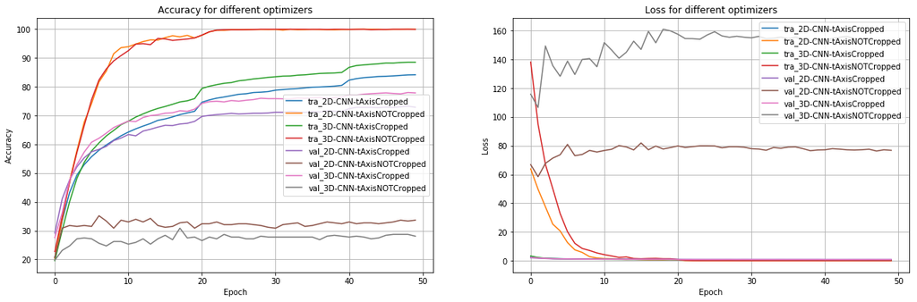

```python
training_curves = {}

for my_cfg in myList:

    curve_name_gen(my_cfg)

    """ PREPARE DATALOADERS """
    train_dl, val_dl, test_dl, input_dimension_, output_dimension_ = get_dataloader_objects(my_cfg)


    """CLASSIFICATION"""
    # Get the model
    model_untrained = get_nn_model(my_cfg, input_dimension=input_dimension_,output_dimension=output_dimension_)

    # Get the optimizer
    optimizer = get_optimizer(my_cfg, model_untrained.parameters())

    # Train and show validation loss
    train_losses, train_accuracies, val_losses, val_accuracies, model_trained, time_spent_for_training_s =\
        fit(train_dl, val_dl, model_untrained, optimizer, my_cfg)

    curves = train_losses, train_accuracies, val_losses, val_accuracies, model_trained, time_spent_for_training_s
    training_curves[my_cfg.curve_name] = curves

    # Report final accuracy
    test_loss, test_accuracy =  final_test_acc(model_trained, test_dl, my_cfg)

    # Save the model
    todays_date = datetime.today().strftime('%Y%m%d_%H%M%S')
    todays_date = 'TrainedModel/'+todays_date
    todays_date_all = todays_date + '_all'
    torch.save(model_trained.state_dict(), todays_date)
    torch.save(model_trained, todays_date_all)

    # Store the results
    results_storer.store_results_for_plot(my_cfg,test_loss, test_accuracy, train_losses,
                                 train_accuracies, time_spent_for_training_s, val_losses, val_accuracies)

    results_storer.store_results(my_cfg, model_trained, optimizer, test_loss, test_accuracy, train_losses,
                                 train_accuracies, time_spent_for_training_s, val_losses, val_accuracies, test_dl)

"""Creates a figure with results and saves it"""
FigName = datetime.today().strftime('%Y%m%d_%H%M%S')
FigName = "Results/Figures/"+ FigName+".eps"
plot_all_metrics(training_curves)
plt.savefig(FigName, format='eps')
```